# Programming and Data Analysis

## Calling various methods of axes object to generate main plot

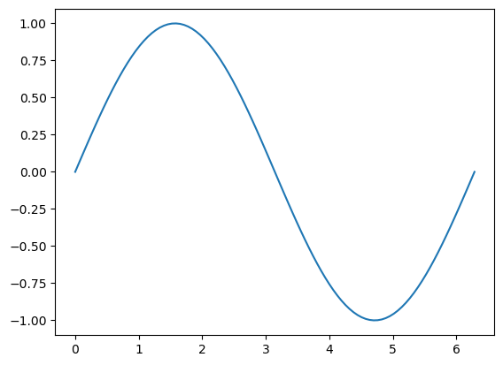

```python
fig, ax = plt.subplots()
ax.plot(x, y)
```

## Calling various methods of axes object to add elements

```python
fig, ax = plt.subplots()
ax.plot(x, y)
ax.set_title('A simple plot')
ax.set_xlabel('x')
```

## Show plots

```python
fig, ax = plt.subplots()
ax.plot(x, y)
ax.set_title('A simple plot')
ax.set_xlabel('x')
plt.show()
```

## Save plots

Various format is supported.

```python
fig = plt.figure()
fig.canvas.get_supported_filetypes()
```

```
{'eps': 'Encapsulated Postscript',
 'jpg': 'Joint Photographic Experts Group',
 'jpeg': 'Joint Photographic Experts Group',
 'pdf': 'Portable Document Format',
 'pgf': 'PGF code for LaTeX',
 'png': 'Portable Network Graphics',
 'ps': 'Postscript',
 'raw': 'Raw RGBA bitmap',
 'rgba': 'Raw RGBA bitmap',
 'svg': 'Scalable Vector Graphics',
 'svgz': 'Scalable Vector Graphics',
 'tif': 'Tagged Image File Format',
 'tiff': 'Tagged Image File Format',
 'webp': 'WebP Image Format'}
```

```python
fig, ax = plt.subplots()
ax.plot(x, y)
ax.set_title('A simple plot')
ax.set_xlabel('x')
fig.savefig('a_simple_plot.png')
```

## Different methods for different plot types

- `scatter()` for scatter plots.
- `hist()` for histograms.
- `plot()` for lines.
- `bar()` for bar plots.
- `barh()` for horizontal bar plots.
- ...etc.

## Import `03-09-2023.csv` as data source

https://github.com/CSSEGISandData/COVID-19/blob/master/csse_covid_19_data/csse_covid_19_daily_reports/03-09-2023.csv

```python
daily_report = pd.read_csv("https://raw.githubusercontent.com/CSSEGISandData/COVID-19/master\
/csse_covid_19_data/csse_covid_19_daily_reports/03-09-2023.csv")
```

## `scatter()` for scatter plots

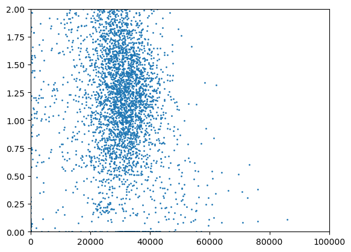

```python
x = daily_report["Incident_Rate"].values
y = daily_report["Case_Fatality_Ratio"].values
fig, ax = plt.subplots()
ax.scatter(x, y, s=1)
ax.set_ylim(0, 2)
ax.set_xlim(0, 100000)
plt.show()
```

## `hist()` for histograms

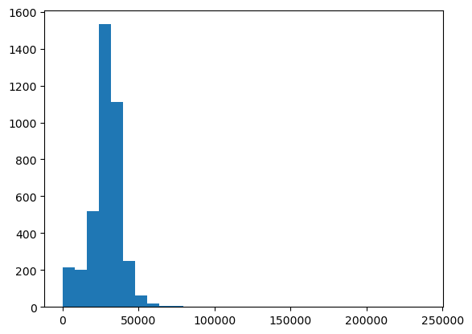

```python
x = daily_report["Incident_Rate"].values # cases per 100,000 persons
fig, ax = plt.subplots()
ax.hist(x, bins=30)
plt.show()
```

## Import data source for line plot

```python
def get_confirmed_time_series():
    request_url = "https://raw.githubusercontent.com/CSSEGISandData/COVID-19/master/csse_covid_19_data/csse_covid_19_time_series/time_series_covid19_confirmed_global.csv"
    time_series = pd.read_csv(request_url)
    id_cols = time_series.columns[:4]
    time_series_long = pd.melt(time_series, id_vars=id_cols, var_name='Date',
                               value_name='Confirmed')
    date = pd.to_datetime(time_series_long['Date'], format="%m/%d/%y")
    time_series_long = time_series_long.drop('Date', axis=1)
    time_series_long.insert(4, 'Date', date)
    groupby_series = time_series_long.groupby(['Country/Region', 'Date'])['Confirmed'].sum()
    out = pd.DataFrame(groupby_series).reset_index()
    return out

confirmed_time_series = get_confirmed_time_series()
```

## `plot()` for lines

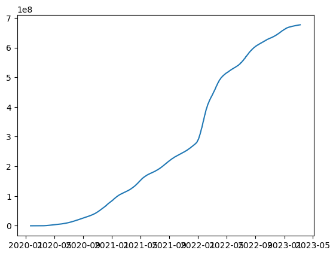

```python
global_ts = confirmed_time_series.groupby("Date")["Confirmed"].sum()
x = global_ts.index
y = global_ts.values
fig, ax = plt.subplots()
ax.plot(x, y)
plt.show()
```

## `bar()` for vertical bar plots

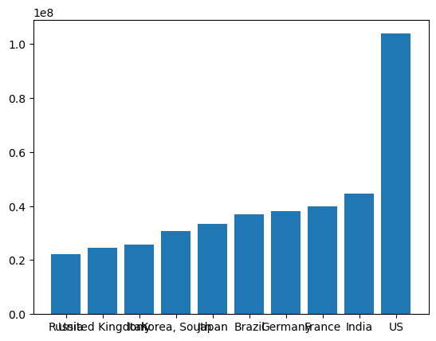

```python
world_top_ten = daily_report.groupby('Country_Region')['Confirmed'].sum().sort_values()[-10:]
fig, ax = plt.subplots()
x = world_top_ten.index
height = world_top_ten.values
ax.bar(x, height)
plt.show()
```

## `barh()` for horizontal bar plots

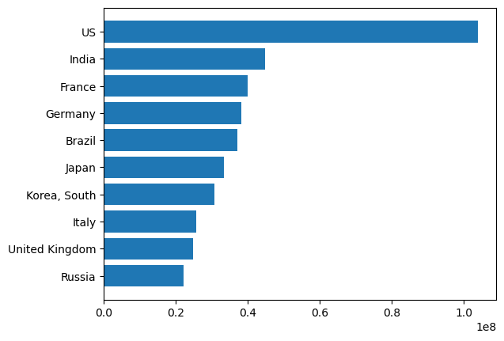

```python
fig, ax = plt.subplots()
y = world_top_ten.index
width = world_top_ten.values
ax.barh(y, width)
plt.show()
```

## Techniques for adding elements

## How to add title and axis labels

- `set_title()` to add title.
- `set_xlabel()` to add x-axis label.
- `set_ylabel()` to add y-axis label.

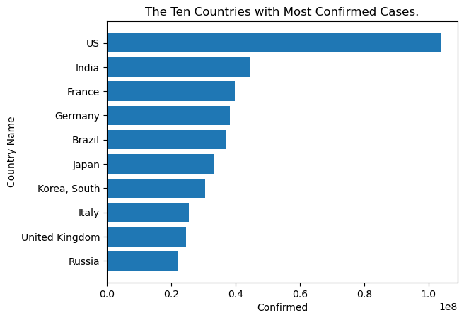

```python
fig, ax = plt.subplots()
y = world_top_ten.index
width = world_top_ten.values
ax.barh(y, width)
ax.set_title('The Ten Countries with Most Confirmed Cases.')
ax.set_xlabel('Confirmed')
ax.set_ylabel('Country Name')
plt.show()
```

## How to adjust axis ticks

- `set_xticks()` to adjust x-axis ticks.
- `set_yticks()` to adjust y-axis ticks.

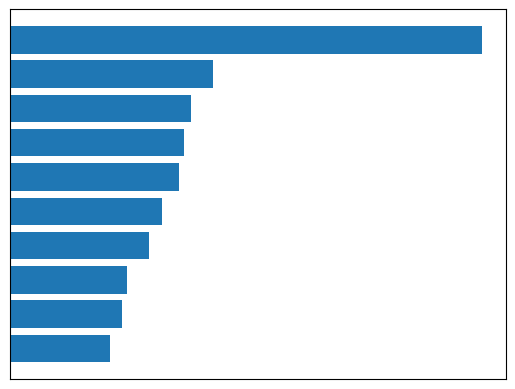

```python
fig, ax = plt.subplots()
y = world_top_ten.index
width = world_top_ten.values
ax.barh(y, width)
ax.set_xticks([])
ax.set_yticks([])
plt.show()
```

## How to adjust axis tick labels

- `set_xticklabels()` to adjust x-axis tick labels.
- `set_yticklabels()` to adjust y-axis tick labels.

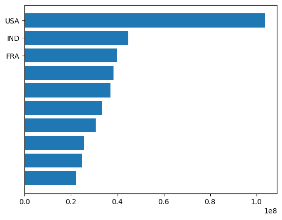

```python
fig, ax = plt.subplots()
y = world_top_ten.index
width = world_top_ten.values
ax.barh(y, width)
ax.set_yticks([7, 8, 9])
ax.set_yticklabels(["FRA", "IND", "USA"])
plt.show()
```

## How to adjust axis limits

- `set_xlim()` to adjust the upper/lower limits of x-axis.
- `set_ylim()` to adjust the upper/lower limits of y-axis.

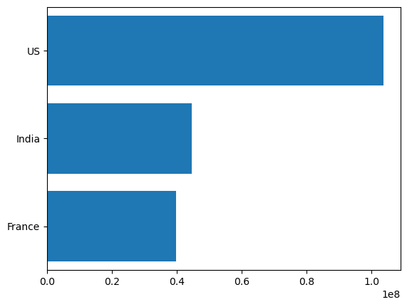

```python
fig, ax = plt.subplots()
y = world_top_ten.index
width = world_top_ten.values
ax.barh(y, width)
ax.set_ylim(6.5, 9.5)
plt.show()
```

## How to add texts

`text(x, y, 'Some Strings')` to add `'Some Strings'` at (x, y).

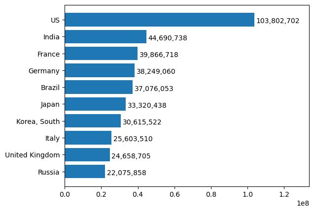

```python
fig, ax = plt.subplots()
ax.barh(world_top_ten.index, world_top_ten.values)
for i in range(world_top_ten.size):
    v = world_top_ten.values[i]
    ax.text(v + 1000000, i - 0.2, f"{v:,}")
ax.set_xlim(0, world_top_ten.max() + 3e7)
plt.show()
```

## How to add legends

`legend()` and `label` parameter to add a legend to indicate categories.

```python
def plot_lines_with_legends(country_names, ts_df):
    fig, ax = plt.subplots()
    for country in country_names:
        country_data = ts_df[ts_df['Country/Region'].str.contains(country)]
        x = country_data['Date']
        y = country_data['Confirmed']
        ax.plot(x, y, label=country)
    ax.set_xlabel('Date')
    ax.set_title('Cumulative COVID-19 confirmed cases')
    ax.legend()
    plt.show()
```

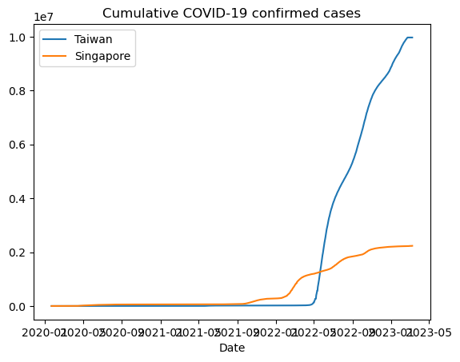

```python
plot_lines_with_legends(['Taiwan', 'Singapore'], confirmed_time_series)
```

## How to solve the problem that matplotlib supporting only English and European fonts?

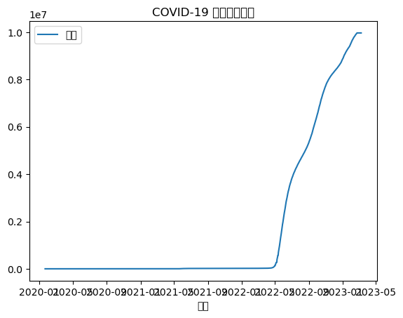

```python
fig, ax = plt.subplots()
tw = confirmed_time_series[confirmed_time_series['Country/Region'].str.contains('Taiwan')]
ax.plot(tw['Date'].values, tw['Confirmed'].values, label='台灣')
ax.set_title('COVID-19 累計確診人數')
ax.set_xlabel('日期')
ax.legend()
plt.show()
```

## Calling `FontProperties` function from `matplotlib.font_manager`

```python
from matplotlib.font_manager import FontProperties

my_font = FontProperties(fname="/System/Library/Fonts/STHeiti Light.ttc") # Specify a font supporting Chinese
```

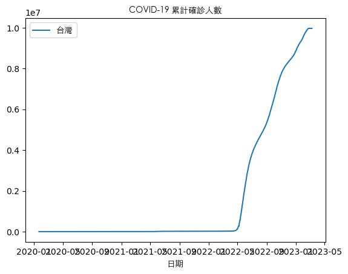

```python
fig, ax = plt.subplots()
tw = confirmed_time_series[confirmed_time_series['Country/Region'].str.contains('Taiwan')]
ax.plot(tw['Date'].values, tw['Confirmed'].values, label='台灣')
ax.set_title('COVID-19 累計確診人數', fontproperties=my_font)
ax.set_xlabel('日期', fontproperties=my_font)
ax.legend(prop=my_font)
plt.show()
```

## How to create a subplot grid?

- `subplots(m, n)` to create a `ndarray` with a shape `(m, n)`.
- There are (m, n) axes objects inside the `ndarray`.
- Access axes objects through `[m, n]`.

```
<class 'numpy.ndarray'>
(2, 3)
```

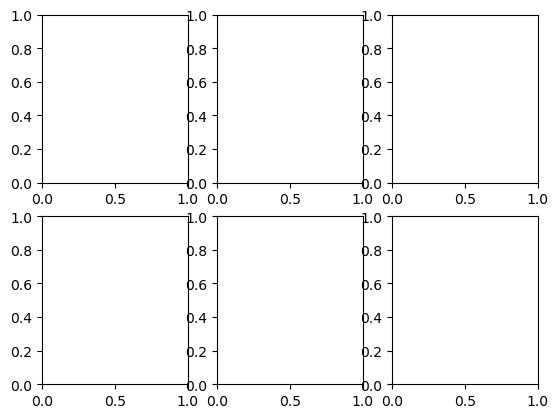

```python
fig, axes = plt.subplots(2, 3)
print(type(axes))
print(axes.shape)
```

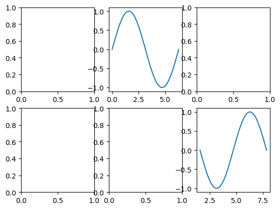

```python
x_sin = np.linspace(0, 2*np.pi, 100)
x_cos = np.linspace(0.5*np.pi, 2.5*np.pi, 100)
y_sin = np.sin(x_sin)
y_cos = np.cos(x_cos)
fig, axes = plt.subplots(2, 3)
axes[0, 1].plot(x_sin, y_sin)
axes[1, 2].plot(x_cos, y_cos)
plt.show()
```